QUESTION 2

```python
import pandas as pd

# Load the cleaned dataset
file_path = r'C:\Users\FahadPansota\Desktop\University\Semester 3\Financial Analytics - 632\Week 6\Data\Q2\Q2 Data - Cleaned.xlsx'
cleaned_data = pd.read_excel(file_path, sheet_name='Sheet1')
```

QUESTION 2 - PART 1 STARTS HERE

Part 1 - Calculating the Arithemetic Average Return

```python
# Convert the Date column to a proper datetime format
cleaned_data['Date yyyy/mm'] = pd.to_datetime(cleaned_data['Date yyyy/mm'], format='%Y%m')

# Set the Date column as the index
cleaned_data.set_index('Date yyyy/mm', inplace=True)

# Drop the columns that are not needed for industry-specific analysis
industry_data = cleaned_data.drop(columns=['1-month Return on risk free (RF)', 'Market excess return (Mkt-RF)'])

# Calculate the 12-month rolling average return for each industry
rolling_means = industry_data.rolling(window=12, min_periods=12).mean().shift(1)

# Filter the data to start from 1927/07
result = rolling_means.loc['1927-07':]

# Display the first 10 and last 10 rows of the filtered returns
with pd.option_context('display.max_rows', 10, 'display.min_rows', 10, 'display.max_columns', None):
    print(result)
```

```
                  Food      Beer     Smoke     Games     Books     Hshld  \
Date yyyy/mm
1927-07-01    0.016150  0.041758  0.031417  0.001783  0.041417  0.009667
1927-08-01    0.019900  0.049908  0.034017  0.000517  0.033758  0.014683
1927-09-01    0.019550  0.024067  0.031792  0.004342  0.029967  0.018100
1927-10-01    0.023583  0.026558  0.034692  0.002883  0.039158  0.019625
1927-11-01    0.024142  0.028650  0.033533  0.006608  0.033458  0.021992
...                ...       ...       ...       ...       ...       ...
2010-08-01    0.007583  0.013533  0.018458  0.034850  0.017292  0.013092
2010-09-01    0.006725  0.014125  0.018108  0.025775  0.001767  0.010558
2010-10-01    0.007283  0.011817  0.022500  0.028950  0.011442  0.008417
2010-11-01    0.013600  0.012558  0.027475  0.047500  0.018600  0.011500
2010-12-01    0.008492  0.009800  0.022458  0.047175  0.013075  0.003392

                 Clths      Hlth     Chems     Txtls     Cnstr     Steel  \
Date yyyy/mm
1927-07-01    0.017300  0.022383  0.038308  0.032392  0.012792  0.012050
1927-08-01    0.015583  0.029217  0.046442  0.035233  0.016392  0.017325
1927-09-01    0.018950  0.025692  0.043683  0.029117  0.011550  0.018858
1927-10-01    0.023267  0.029892  0.044233  0.028558  0.015758  0.021725
1927-11-01    0.031225  0.034775  0.042008  0.026417  0.015775  0.018358
...                ...       ...       ...       ...       ...       ...
2010-08-01    0.025475  0.004825  0.020917  0.015583  0.007508  0.008425
2010-09-01    0.016783  0.001667  0.019417  0.009783 -0.003333 -0.002008
2010-10-01    0.020917  0.007200  0.022033  0.020033  0.005692  0.002900
2010-11-01    0.026258  0.011925  0.032383  0.028333  0.013083  0.016808
2010-12-01    0.032333  0.002292  0.024942  0.025225  0.015025  0.013092

                 FabPr     ElcEq     Autos     Carry     Mines      Coal  \
Date yyyy/mm
1927-07-01    0.026983  0.019392  0.035717  0.015200  0.025158  0.012242
1927-08-01    0.030425  0.028650  0.033467  0.024408  0.028600  0.012783
1927-09-01    0.029408  0.032733  0.036108  0.026258  0.027817  0.014100
1927-10-01    0.033542  0.033567  0.037317  0.027217  0.034358  0.015067
1927-11-01    0.028275  0.031558  0.040133  0.026050  0.034383  0.008767
...                ...       ...       ...       ...       ...       ...
2010-08-01    0.025592  0.024600  0.034900  0.029742  0.024117  0.023975
2010-09-01    0.016725  0.017025  0.025717  0.014050  0.023050  0.017775
2010-10-01    0.023150  0.022333  0.036667  0.017733  0.023942  0.015300
2010-11-01    0.027583  0.030850  0.047175  0.026433  0.030100  0.020925
```

[output cut: 16 more lines]

```
                 Trans     Whlsl     Rtail     Meals       Fin     Other
Date yyyy/mm
1927-07-01    0.018983 -0.067650  0.004367  0.017283  0.016100  0.002383
1927-08-01    0.022417 -0.038567  0.014858  0.019658  0.022483  0.003725
1927-09-01    0.016950 -0.045208  0.026650  0.020192  0.020050  0.003025
1927-10-01    0.020492 -0.033983  0.030767  0.025625  0.026142  0.006600
1927-11-01    0.018875 -0.039317  0.030108  0.027608  0.034108  0.010658
...                ...       ...       ...       ...       ...       ...
2010-08-01    0.024800  0.018417  0.009583  0.025442  0.010925  0.015608
2010-09-01    0.017658  0.008233  0.002825  0.023233 -0.004433  0.009292
2010-10-01    0.023158  0.013100  0.012458  0.026383  0.000458  0.009750
2010-11-01    0.032208  0.019542  0.012800  0.033817  0.005925  0.014467
2010-12-01    0.024792  0.016025  0.013150  0.030817  0.002075  0.008625

[1002 rows x 30 columns]
```

Ranking the Industries

```python
# Rank the industries based on their past average return for each month
ranked_data = result.rank(axis=1, method='min')

# Display the first 10 and last 10 rows of the ranked data
with pd.option_context('display.max_rows', 10, 'display.min_rows', 10, 'display.max_columns', None):
    print("Monthly Industry Ranks:")
    print(ranked_data)
```

```
Monthly Industry Ranks:
              Food  Beer  Smoke  Games  Books  Hshld  Clths  Hlth  Chems  \
Date yyyy/mm
1927-07-01    14.0  30.0   24.0    3.0   29.0    7.0   17.0  20.0   28.0
1927-08-01    15.0  30.0   27.0    3.0   26.0    8.0   10.0  22.0   29.0
1927-09-01    14.0  17.0   26.0    4.0   24.0   10.0   13.0  18.0   30.0
1927-10-01    13.0  17.0   27.0    3.0   29.0    8.0   12.0  20.0   30.0
1927-11-01    13.0  18.0   24.0    3.0   23.0   10.0   20.0  27.0   30.0
...            ...   ...    ...    ...    ...    ...    ...   ...    ...
2010-08-01     4.0  11.0   18.0   29.0   15.0   10.0   26.0   2.0   19.0
2010-09-01    10.0  18.0   24.0   30.0    6.0   16.0   20.0   5.0   25.0
2010-10-01     6.0  12.0   24.0   29.0   11.0    7.0   20.0   5.0   22.0
2010-11-01     8.0   5.0   20.0   30.0   13.0    3.0   18.0   4.0   27.0
2010-12-01     5.0   8.0   20.0   30.0   11.0    3.0   28.0   2.0   23.0

              Txtls  Cnstr  Steel  FabPr  ElcEq  Autos  Carry  Mines  Coal  \
Date yyyy/mm
1927-07-01     25.0   10.0    8.0   22.0   19.0   27.0   11.0   21.0   9.0
1927-08-01     28.0   11.0   12.0   23.0   21.0   25.0   18.0   20.0   6.0
1927-09-01     22.0    6.0   12.0   23.0   28.0   29.0   19.0   21.0   7.0
1927-10-01     19.0    6.0   11.0   23.0   24.0   28.0   18.0   26.0   5.0
1927-11-01     15.0    6.0    7.0   17.0   22.0   29.0   14.0   26.0   4.0
...             ...    ...    ...    ...    ...    ...    ...    ...   ...
2010-08-01     13.0    3.0    5.0   27.0   23.0   30.0   28.0   22.0  21.0
2010-09-01     15.0    2.0    3.0   19.0   21.0   29.0   17.0   27.0  23.0
2010-10-01     19.0    4.0    2.0   25.0   23.0   30.0   18.0   27.0  17.0
2010-11-01     23.0    7.0   12.0   21.0   25.0   29.0   19.0   24.0  17.0
2010-12-01     24.0   14.0   12.0   25.0   26.0   29.0   17.0   18.0  21.0

              Oil  Util  Telcm  Servs  BusEq  Paper  Trans  Whlsl  Rtail  \
Date yyyy/mm
1927-07-01    2.0  12.0   15.0   26.0   23.0    4.0   18.0    1.0    6.0
1927-08-01    2.0   7.0   13.0   19.0   24.0    5.0   16.0    1.0    9.0
1927-09-01    2.0  11.0    9.0   27.0   25.0    5.0    8.0    1.0   20.0
1927-10-01    2.0  14.0   10.0   22.0   25.0    7.0    9.0    1.0   21.0
1927-11-01    2.0  11.0    9.0   28.0   21.0   12.0    8.0    1.0   19.0
...           ...   ...    ...    ...    ...    ...    ...    ...    ...
2010-08-01    1.0   6.0   20.0    9.0   12.0   16.0   24.0   17.0    7.0
2010-09-01    4.0  13.0   26.0    8.0    9.0   14.0   22.0   11.0    7.0
2010-10-01    3.0   9.0   21.0   10.0   14.0   16.0   26.0   15.0   13.0
2010-11-01    2.0   9.0   22.0   11.0   16.0   14.0   26.0   15.0    6.0
2010-12-01    4.0   7.0   19.0    9.0   16.0   10.0   22.0   15.0   13.0

              Meals   Fin  Other
Date yyyy/mm
1927-07-01     16.0  13.0    5.0
1927-08-01     14.0  17.0    4.0
1927-09-01     16.0  15.0    3.0
1927-10-01     15.0  16.0    4.0
1927-11-01     16.0  25.0    5.0
...             ...   ...    ...
2010-08-01     25.0   8.0   14.0
2010-09-01     28.0   1.0   12.0
2010-10-01     28.0   1.0    8.0
2010-11-01     28.0   1.0   10.0
2010-12-01     27.0   1.0    6.0

[1002 rows x 30 columns]
```

Ranking Methodology:

The rank method ranks the values in ascending order, meaning the lowest value (lowest past average return) gets rank 1, the next lowest value gets rank 2, and so on. Conversely, the highest value (highest past average return) gets the highest rank number (e.g., if there are 30 industries, the highest rank would be 30).

```python
# Compute each industry's average rank
average_rank = ranked_data.mean()

# Display the average rank
print("Average Rank of Each Industry:")
print(average_rank)
```

```
Average Rank of Each Industry:
Food     15.184631
Beer     16.386228
Smoke    16.216567
Games    16.247505
Books    14.975050
Hshld    14.939122
Clths    14.539920
Hlth     15.657685
Chems    15.489022
Txtls    15.239521
Cnstr    14.907186
Steel    14.890220
FabPr    15.762475
ElcEq    17.166667
Autos    16.009980
Carry    16.521956
Mines    14.960080
Coal     16.004990
Oil      15.910180
Util     14.770459
Telcm    14.087824
Servs    16.407186
BusEq    16.089820
Paper    15.510978
Trans    15.000998
Whlsl    14.766467
Rtail    15.377246
Meals    15.952096
Fin      15.802395
Other    14.213573
dtype: float64
```

Part 1 - A&B - Industries with Highest and Lowest average rank

```python
# Identify the industry with the lowest and highest average rank
lowest_avg_rank_industry = average_rank.idxmin()
highest_avg_rank_industry = average_rank.idxmax()

# Get the average ranks of these industries
lowest_avg_rank = average_rank[lowest_avg_rank_industry]
highest_avg_rank = average_rank[highest_avg_rank_industry]

print(f"Industry with the lowest average rank: {lowest_avg_rank_industry} (Average Rank: {lowest_avg_rank})")
print(f"Industry with the highest average rank: {highest_avg_rank_industry} (Average Rank: {highest_avg_rank})")
```

```
Industry with the lowest average rank: Telcm (Average Rank: 14.087824351297405)
Industry with the highest average rank: ElcEq (Average Rank: 17.166666666666668)
```

Part 1- C - Plot of the rank of Autos industry over time

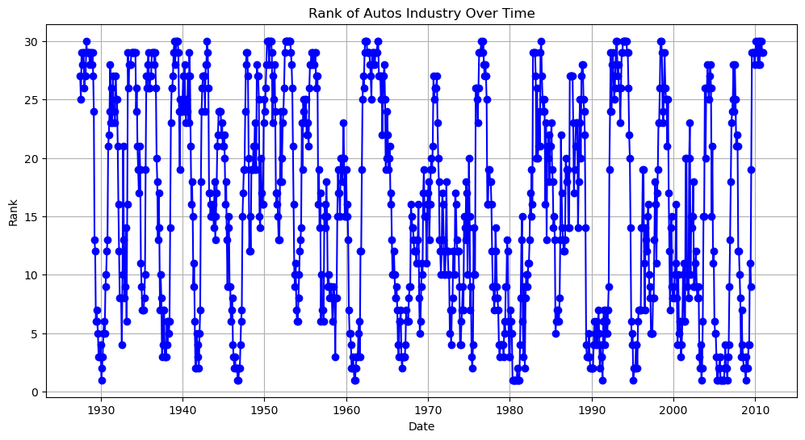

```python
import matplotlib.pyplot as plt

# Plot the rank of the Autos industry over time
plt.figure(figsize=(12, 6))
plt.plot(ranked_data.index, ranked_data['Autos'], marker='o', linestyle='-', color='b')
plt.title('Rank of Autos Industry Over Time')
plt.xlabel('Date')
plt.ylabel('Rank')
plt.grid(True)
plt.show()
```

Part 1- C - Plot of the Top and Bottom Industry

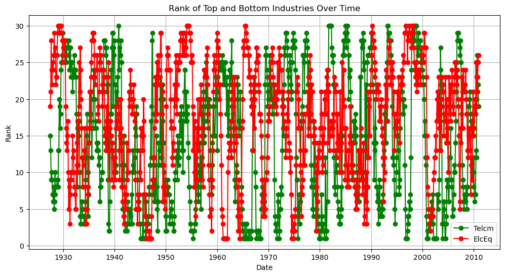

```python
import matplotlib.pyplot as plt

# Plot the rank of the top industry (Telcm) over time
plt.figure(figsize=(12, 6))
plt.plot(ranked_data.index, ranked_data['Telcm'], marker='o', linestyle='-', color='g', label='Telcm')
plt.plot(ranked_data.index, ranked_data['ElcEq'], marker='o', linestyle='-', color='r', label='ElcEq')
plt.title('Rank of Top and Bottom Industries Over Time')
plt.xlabel('Date')
plt.ylabel('Rank')
plt.legend()
plt.grid(True)
plt.show()
```

Part 1 - D - Analysis of Stability and Turnover

Conclusion

Is industry momentum a long-term bet on a few industries or a very dynamic strategy?

Dynamic Strategy: The significant movement in ranks indicates that industry momentum is a dynamic strategy rather than a long-term bet on a few industries. The ranks change frequently, reflecting a strategy that adapts to changing performance trends among industries.

Do you expect high or low turnover from this strategy?

High Turnover: Given the frequent changes in ranks, we can expect high turnover from the industry momentum strategy. This is because the strategy would require frequent rebalancing to capture the performance shifts among industries.

Summary

The plot reveals that the top and bottom industries experience significant rank fluctuations over time. This indicates that industry momentum is a dynamic strategy with high turnover, as it continuously adapts to the changing performance of different industries.

QUESTION 2 - PART 2 STARTS HERE

Part 2 - Winner Industries with Average Returns

```python
import pandas as pd

# Load the cleaned dataset
file_path = r'C:\Users\FahadPansota\Desktop\University\Semester 3\Financial Analytics - 632\Week 6\Data\Q2\Q2 Data - Cleaned.xlsx'
cleaned_data = pd.read_excel(file_path, sheet_name='Sheet1')

# Convert the Date column to a proper datetime format
cleaned_data['Date yyyy/mm'] = pd.to_datetime(cleaned_data['Date yyyy/mm'], format='%Y%m')

# Set the Date column as the index
cleaned_data.set_index('Date yyyy/mm', inplace=True)

# Drop the columns that are not needed for industry-specific analysis
industry_data = cleaned_data.drop(columns=['1-month Return on risk free (RF)', 'Market excess return (Mkt-RF)'])

# Calculate the 12-month rolling average return for each industry
rolling_means = industry_data.rolling(window=12, min_periods=12).mean().shift(1)

# Filter the data to start from 1927/07
result = rolling_means.loc['1927-07':]

# Rank the industries based on their past 12-month rolling average return for each month
ranked_data = result.rank(axis=1, method='min')

# Combine returns and ranks into a DataFrame with interleaved columns
combined_data = pd.DataFrame()

for column in result.columns:
    combined_data[f'{column}_Return'] = result[column]
    combined_data[f'{column}_Rank'] = ranked_data[column]

# Display the first 10 and last 10 rows of the filtered returns and their ranks together
with pd.option_context('display.max_rows', 10, 'display.min_rows', 10, 'display.max_columns', None):
    print("Rolling Average Returns and Their Corresponding Ranks:")
    print(combined_data)

# To make it easier for us we have placed the returns and ranks simultaneously
```

```
Rolling Average Returns and Their Corresponding Ranks:
              Food_Return  Food_Rank  Beer_Return  Beer_Rank  Smoke_Return  \
Date yyyy/mm
1927-07-01       0.016150       14.0     0.041758       30.0      0.031417
1927-08-01       0.019900       15.0     0.049908       30.0      0.034017
1927-09-01       0.019550       14.0     0.024067       17.0      0.031792
1927-10-01       0.023583       13.0     0.026558       17.0      0.034692
1927-11-01       0.024142       13.0     0.028650       18.0      0.033533
...                   ...        ...          ...        ...           ...
2010-08-01       0.007583        4.0     0.013533       11.0      0.018458
2010-09-01       0.006725       10.0     0.014125       18.0      0.018108
2010-10-01       0.007283        6.0     0.011817       12.0      0.022500
2010-11-01       0.013600        8.0     0.012558        5.0      0.027475
2010-12-01       0.008492        5.0     0.009800        8.0      0.022458

              Smoke_Rank  Games_Return  Games_Rank  Books_Return  Books_Rank  \
Date yyyy/mm
1927-07-01          24.0      0.001783         3.0      0.041417        29.0
1927-08-01          27.0      0.000517         3.0      0.033758        26.0
1927-09-01          26.0      0.004342         4.0      0.029967        24.0
1927-10-01          27.0      0.002883         3.0      0.039158        29.0
1927-11-01          24.0      0.006608         3.0      0.033458        23.0
...                  ...           ...         ...           ...         ...
2010-08-01          18.0      0.034850        29.0      0.017292        15.0
2010-09-01          24.0      0.025775        30.0      0.001767         6.0
2010-10-01          24.0      0.028950        29.0      0.011442        11.0
2010-11-01          20.0      0.047500        30.0      0.018600        13.0
2010-12-01          20.0      0.047175        30.0      0.013075        11.0

              Hshld_Return  Hshld_Rank  Clths_Return  Clths_Rank  Hlth_Return  \
Date yyyy/mm
1927-07-01        0.009667         7.0      0.017300        17.0     0.022383
1927-08-01        0.014683         8.0      0.015583        10.0     0.029217
1927-09-01        0.018100        10.0      0.018950        13.0     0.025692
1927-10-01        0.019625         8.0      0.023267        12.0     0.029892
1927-11-01        0.021992        10.0      0.031225        20.0     0.034775
...                    ...         ...           ...         ...          ...
2010-08-01        0.013092        10.0      0.025475        26.0     0.004825
2010-09-01        0.010558        16.0      0.016783        20.0     0.001667
2010-10-01        0.008417         7.0      0.020917        20.0     0.007200
```

[output cut: 143 more lines]

```
              Other_Rank
Date yyyy/mm
1927-07-01           5.0
1927-08-01           4.0
1927-09-01           3.0
1927-10-01           4.0
1927-11-01           5.0
...                  ...
2010-08-01          14.0
2010-09-01          12.0
2010-10-01           8.0
2010-11-01          10.0
2010-12-01           6.0

[1002 rows x 60 columns]
```

In next step We have just taken out industries returns who ranked more than 15

```python
# Initialize a dictionary to store the filtered returns and ranks for each month
filtered_data = {}

# Loop through each month
for date in ranked_data.index:
    # Identify industries with ranks > 15
    high_rank_industries = ranked_data.loc[date][ranked_data.loc[date] > 15].index

    # Get returns and ranks for those industries
    returns_for_high_ranks = result.loc[date, high_rank_industries]
    ranks_for_high_ranks = ranked_data.loc[date, high_rank_industries]

    # Store the returns and ranks in the dictionary
    filtered_data[date] = pd.DataFrame({
        'Return': returns_for_high_ranks,
        'Rank': ranks_for_high_ranks
    })

# Convert the dictionary to a pandas DataFrame for easier viewing
filtered_combined_data = pd.concat(filtered_data, axis=0).reset_index(level=1)

# Display the first 10 and last 10 rows of the filtered returns and ranks
with pd.option_context('display.max_rows', 10, 'display.min_rows', 10, 'display.max_columns', None):
    print("Filtered Returns and Their Corresponding Ranks (Ranks > 15):")
    print(filtered_combined_data)
```

```
Filtered Returns and Their Corresponding Ranks (Ranks > 15):
           level_1    Return  Rank
1927-07-01    Beer  0.041758  30.0
1927-07-01   Smoke  0.031417  24.0
1927-07-01   Books  0.041417  29.0
1927-07-01   Clths  0.017300  17.0
1927-07-01    Hlth  0.022383  20.0
...            ...       ...   ...
2010-12-01    Coal  0.024092  21.0
2010-12-01   Telcm  0.020625  19.0
2010-12-01   BusEq  0.017242  16.0
2010-12-01   Trans  0.024792  22.0
2010-12-01   Meals  0.030817  27.0

[15029 rows x 3 columns]
```

Monthly Averages of Winner Portfolio

```python
# Initialize a dictionary to store the filtered returns and ranks for each month
filtered_data = {}

# Loop through each month
for date in ranked_data.index:
    # Identify industries with ranks > 15
    high_rank_industries = ranked_data.loc[date][ranked_data.loc[date] > 15].index

    # Get returns and ranks for those industries
    returns_for_high_ranks = result.loc[date, high_rank_industries]
    ranks_for_high_ranks = ranked_data.loc[date, high_rank_industries]

    # Store the returns and ranks in the dictionary
    filtered_data[date] = pd.DataFrame({
        'Return': returns_for_high_ranks,
        'Rank': ranks_for_high_ranks
    })

# Convert the dictionary to a pandas DataFrame for easier viewing
filtered_combined_data = pd.concat(filtered_data, axis=0).reset_index(level=1)

# Calculate the average return for each month
average_returns_winner_portfolio = filtered_combined_data.groupby(level=0)['Return'].mean()

# Display the first 10 and last 10 rows of the average returns
with pd.option_context('display.max_rows', 10, 'display.min_rows', 10, 'display.max_columns', None):
    print("Average Monthly Returns of Industries with Ranks > 15 (Winner Portfolio):")
    print(average_returns_winner_portfolio)
```

```
Average Monthly Returns of Industries with Ranks > 15 (Winner Portfolio):
1927-07-01    0.028716
1927-08-01    0.031911
1927-09-01    0.029777
1927-10-01    0.032828
1927-11-01    0.033272
                ...
2010-08-01    0.024769
2010-09-01    0.018658
2010-10-01    0.022603
2010-11-01    0.030586
2010-12-01    0.027345
Name: Return, Length: 1002, dtype: float64
```

Part 2 - A - Average of Monthly Excess returns

```python
# Load the risk-free return data
risk_free_rate = cleaned_data['1-month Return on risk free (RF)'].loc['1927-07':]

# Calculate the excess returns by subtracting the risk-free rate from the average returns
excess_returns_winner_portfolio = average_returns - risk_free_rate

# Display the first 10 and last 10 rows of the excess returns
with pd.option_context('display.max_rows', 10, 'display.min_rows', 10, 'display.max_columns', None):
    print("Average Monthly Excess Returns of Winner Portfolio:")
    print(excess_returns_winner_portfolio)
```

```
Average Monthly Excess Returns of Winner Portfolio:
1927-07-01    0.025716
1927-08-01    0.029111
1927-09-01    0.027677
1927-10-01    0.030328
1927-11-01    0.031172
                ...
2010-08-01    0.024669
2010-09-01    0.018558
2010-10-01    0.022503
2010-11-01    0.030486
2010-12-01    0.027245
Length: 1002, dtype: float64
```

```python
# Calculate the average of the excess monthly returns for winner portfolio
average_excess_return_winner_portfolio = excess_returns_winner_portfolio.mean()

# Display the average excess return
print("Average Monthly Excess Return of Winner Portfolio:")
print(average_excess_return_winner_portfolio)
```

```
Average Monthly Excess Return of Winner Portfolio:
0.016488958551151667
```

Part 2 - B - St Dev of Excess Monthly returns

```python
# Calculate the standard deviation of the monthly excess returns for winner portfolio
std_excess_return_winner_portfolio = excess_returns_winner_portfolio.std()

# Display the standard deviation
print("Standard Deviation of Monthly Excess Returns:")
print(std_excess_return_winner_portfolio)
```

```
Standard Deviation of Monthly Excess Returns:
0.0182306100774857
```

Part 2 - C - Monthly Sharpe Ratio

```python
# Calculate the monthly Sharpe ratio for winner portfolio
monthly_sharpe_ratio_winner_portfolio = average_excess_return_winner_portfolio / std_excess_return_winner_portfolio

# Display the monthly Sharpe ratio
print("Monthly Sharpe Ratio:")
print(monthly_sharpe_ratio_winner_portfolio)
```

```
Monthly Sharpe Ratio:
0.9044655379643645
```

Part 2 - D - Annualized Sharpe ratio

```python
# Calculate the annualized average excess return for winner portfolio
annualized_average_excess_return_winner_portfolio = average_excess_return_winner_portfolio * 12

# Calculate the annualized standard deviation of excess returns for winner portfolio
annualized_std_excess_return_winner_portfolio = std_excess_return_winner_portfolio * (12 ** 0.5)

# Calculate the annualized Sharpe ratio for winner portfolio
annualized_sharpe_ratio_winner_portfolio = annualized_average_excess_return_winner_portfolio / annualized_std_excess_return_winner_portfolio

# Display the annualized Sharpe ratio
print("Annualized Sharpe Ratio:")
print(annualized_sharpe_ratio_winner_portfolio)
```

```
Annualized Sharpe Ratio:
3.133160530898793
```

QUESTION 2 - PART 3 STARTS HERE

Part 3 - Loser Industries with Average Returns

```python
import pandas as pd

# Load the cleaned dataset
file_path = r'C:\Users\FahadPansota\Desktop\University\Semester 3\Financial Analytics - 632\Week 6\Data\Q2\Q2 Data - Cleaned.xlsx'
cleaned_data = pd.read_excel(file_path, sheet_name='Sheet1')

# Convert the Date column to a proper datetime format
cleaned_data['Date yyyy/mm'] = pd.to_datetime(cleaned_data['Date yyyy/mm'], format='%Y%m')

# Set the Date column as the index
cleaned_data.set_index('Date yyyy/mm', inplace=True)

# Drop the columns that are not needed for industry-specific analysis
industry_data = cleaned_data.drop(columns=['1-month Return on risk free (RF)', 'Market excess return (Mkt-RF)'])

# Calculate the 12-month rolling average return for each industry
rolling_means = industry_data.rolling(window=12, min_periods=12).mean().shift(1)

# Filter the data to start from 1927/07
result = rolling_means.loc['1927-07':]

# Rank the industries based on their past 12-month rolling average return for each month
ranked_data = result.rank(axis=1, method='min')

# Combine returns and ranks into a DataFrame with interleaved columns
combined_data = pd.DataFrame()

for column in result.columns:
    combined_data[f'{column}_Return'] = result[column]
    combined_data[f'{column}_Rank'] = ranked_data[column]

# Display the first 10 and last 10 rows of the filtered returns and their ranks together
with pd.option_context('display.max_rows', 10, 'display.min_rows', 10, 'display.max_columns', None):
    print("Rolling Average Returns and Their Corresponding Ranks:")
    print(combined_data)

# To make it easier for us we have placed the returns and ranks simultaneously
```

```
Rolling Average Returns and Their Corresponding Ranks:
              Food_Return  Food_Rank  Beer_Return  Beer_Rank  Smoke_Return  \
Date yyyy/mm
1927-07-01       0.016150       14.0     0.041758       30.0      0.031417
1927-08-01       0.019900       15.0     0.049908       30.0      0.034017
1927-09-01       0.019550       14.0     0.024067       17.0      0.031792
1927-10-01       0.023583       13.0     0.026558       17.0      0.034692
1927-11-01       0.024142       13.0     0.028650       18.0      0.033533
...                   ...        ...          ...        ...           ...
2010-08-01       0.007583        4.0     0.013533       11.0      0.018458
2010-09-01       0.006725       10.0     0.014125       18.0      0.018108
2010-10-01       0.007283        6.0     0.011817       12.0      0.022500
2010-11-01       0.013600        8.0     0.012558        5.0      0.027475
2010-12-01       0.008492        5.0     0.009800        8.0      0.022458

              Smoke_Rank  Games_Return  Games_Rank  Books_Return  Books_Rank  \
Date yyyy/mm
1927-07-01          24.0      0.001783         3.0      0.041417        29.0
1927-08-01          27.0      0.000517         3.0      0.033758        26.0
1927-09-01          26.0      0.004342         4.0      0.029967        24.0
1927-10-01          27.0      0.002883         3.0      0.039158        29.0
1927-11-01          24.0      0.006608         3.0      0.033458        23.0
...                  ...           ...         ...           ...         ...
2010-08-01          18.0      0.034850        29.0      0.017292        15.0
2010-09-01          24.0      0.025775        30.0      0.001767         6.0
2010-10-01          24.0      0.028950        29.0      0.011442        11.0
2010-11-01          20.0      0.047500        30.0      0.018600        13.0
2010-12-01          20.0      0.047175        30.0      0.013075        11.0

              Hshld_Return  Hshld_Rank  Clths_Return  Clths_Rank  Hlth_Return  \
Date yyyy/mm
1927-07-01        0.009667         7.0      0.017300        17.0     0.022383
1927-08-01        0.014683         8.0      0.015583        10.0     0.029217
1927-09-01        0.018100        10.0      0.018950        13.0     0.025692
1927-10-01        0.019625         8.0      0.023267        12.0     0.029892
1927-11-01        0.021992        10.0      0.031225        20.0     0.034775
...                    ...         ...           ...         ...          ...
2010-08-01        0.013092        10.0      0.025475        26.0     0.004825
2010-09-01        0.010558        16.0      0.016783        20.0     0.001667
2010-10-01        0.008417         7.0      0.020917        20.0     0.007200
```

[output cut: 143 more lines]

```
              Other_Rank
Date yyyy/mm
1927-07-01           5.0
1927-08-01           4.0
1927-09-01           3.0
1927-10-01           4.0
1927-11-01           5.0
...                  ...
2010-08-01          14.0
2010-09-01          12.0
2010-10-01           8.0
2010-11-01          10.0
2010-12-01           6.0

[1002 rows x 60 columns]
```

In next step We have just taken out industries returns who ranked less than 16

```python
# Initialize a dictionary to store the filtered returns and ranks for each month
filtered_data = {}

# Loop through each month
for date in ranked_data.index:
    # Identify industries with ranks < 16
    low_rank_industries = ranked_data.loc[date][ranked_data.loc[date] < 16].index

    # Get returns and ranks for those industries
    returns_for_low_ranks = result.loc[date, low_rank_industries]
    ranks_for_low_ranks = ranked_data.loc[date, low_rank_industries]

    # Store the returns and ranks in the dictionary
    filtered_data[date] = pd.DataFrame({
        'Return': returns_for_low_ranks,
        'Rank': ranks_for_low_ranks
    })

# Convert the dictionary to a pandas DataFrame for easier viewing
filtered_combined_data = pd.concat(filtered_data, axis=0).reset_index(level=1)

# Display the first 10 and last 10 rows of the filtered returns and ranks
with pd.option_context('display.max_rows', 10, 'display.min_rows', 10, 'display.max_columns', None):
    print("Filtered Returns and Their Corresponding Ranks (Ranks < 16):")
    print(filtered_combined_data)
```

```
Filtered Returns and Their Corresponding Ranks (Ranks < 16):
           level_1    Return  Rank
1927-07-01    Food  0.016150  14.0
1927-07-01   Games  0.001783   3.0
1927-07-01   Hshld  0.009667   7.0
1927-07-01   Cnstr  0.012792  10.0
1927-07-01   Steel  0.012050   8.0
...            ...       ...   ...
2010-12-01   Paper  0.012717  10.0
2010-12-01   Whlsl  0.016025  15.0
2010-12-01   Rtail  0.013150  13.0
2010-12-01     Fin  0.002075   1.0
2010-12-01   Other  0.008625   6.0

[15031 rows x 3 columns]
```

Monthly Averages of Loser Portfolio

```python
# Calculate the average return for each month
average_returns_loser_portfolio = filtered_combined_data_loser.groupby(level=0)['Return'].mean()

# Display the first 10 and last 10 rows of the average returns
with pd.option_context('display.max_rows', 10, 'display.min_rows', 10, 'display.max_columns', None):
    print("Average Monthly Returns of Industries with Ranks < 16 (Loser Portfolio):")
    print(average_returns_loser_portfolio)
```

```
Average Monthly Returns of Industries with Ranks < 16 (Loser Portfolio):
1927-07-01    0.004181
1927-08-01    0.008844
1927-09-01    0.009395
1927-10-01    0.013561
1927-11-01    0.013452
                ...
2010-08-01    0.010951
2010-09-01    0.004143
2010-10-01    0.008641
2010-11-01    0.013823
2010-12-01    0.009724
Name: Return, Length: 1002, dtype: float64
```

Part 3 - A - Average of Monthly Excess returns

```python
# Load the risk-free return data
risk_free_rate = cleaned_data['1-month Return on risk free (RF)'].loc['1927-07':]

# Calculate the excess returns by subtracting the risk-free rate from the average returns
excess_returns_loser_portfolio = average_returns_loser_portfolio - risk_free_rate

# Display the first 10 and last 10 rows of the excess returns
with pd.option_context('display.max_rows', 10, 'display.min_rows', 10, 'display.max_columns', None):
    print("Average Monthly Excess Returns of Loser Portfolio:")
    print(excess_returns_loser_portfolio)
```

```
Average Monthly Excess Returns of Loser Portfolio:
1927-07-01    0.001181
1927-08-01    0.006044
1927-09-01    0.007295
1927-10-01    0.011061
1927-11-01    0.011352
                ...
2010-08-01    0.010851
2010-09-01    0.004043
2010-10-01    0.008541
2010-11-01    0.013723
2010-12-01    0.009624
Length: 1002, dtype: float64
```

```python
# Calculate the average of the excess monthly returns
average_excess_return_loser_portfolio = excess_returns_loser_portfolio.mean()

# Display the average excess return
print("Average Monthly Excess Return of Loser Portfolio:")
print(average_excess_return_loser_portfolio)
```

```
Average Monthly Excess Return of Loser Portfolio:
-0.0022436955949212693
```

Part 3 - B - St Dev of Excess Monthly returns

```python
# Calculate the standard deviation of the monthly excess returns
std_excess_return_loser_portfolio = excess_returns_loser_portfolio.std()

# Display the standard deviation
print("Standard Deviation of Monthly Excess Returns of Loser Portfolio:")
print(std_excess_return_loser_portfolio)
```

```
Standard Deviation of Monthly Excess Returns of Loser Portfolio:
0.018049649190817283
```

Part 3 - C - Monthly Sharpe Ratio

```python
# Calculate the monthly Sharpe ratio
monthly_sharpe_ratio_loser_portfolio = average_excess_return_loser_portfolio / std_excess_return_loser_portfolio

# Display the monthly Sharpe ratio
print("Monthly Sharpe Ratio of Loser Portfolio:")
print(monthly_sharpe_ratio_loser_portfolio)
```

```
Monthly Sharpe Ratio of Loser Portfolio:
-0.12430688104801196
```

Part 3 - D - Annualized Sharpe ratio

```python
# Calculate the annualized average excess return
annualized_average_excess_return_loser_portfolio = average_excess_return_loser_portfolio * 12

# Calculate the annualized standard deviation of excess returns
annualized_std_excess_return_loser_portfolio = std_excess_return_loser_portfolio * (12 ** 0.5)

# Calculate the annualized Sharpe ratio
annualized_sharpe_ratio_loser_portfolio = annualized_average_excess_return_loser_portfolio / annualized_std_excess_return_loser_portfolio

# Display the annualized Sharpe ratio
print("Annualized Sharpe Ratio of Loser Portfolio:")
print(annualized_sharpe_ratio_loser_portfolio)
```

```
Annualized Sharpe Ratio of Loser Portfolio:
-0.4306116674111551
```

Part 3 - E - Annualized Sharpe ratio of Overall Market Index

```python
# Calculate the average monthly return across all industries using the rolling averages
average_market_return = result.mean(axis=1)

# Display the first 10 and last 10 rows of the average market returns
with pd.option_context('display.max_rows', 10, 'display.min_rows', 10, 'display.max_columns', None):
    print("Average Monthly Returns of the Overall Market Index (Using Rolling Averages):")
    print(average_market_return)
```

```
Average Monthly Returns of the Overall Market Index (Using Rolling Averages):
Date yyyy/mm
1927-07-01    0.016448
1927-08-01    0.020377
1927-09-01    0.019586
1927-10-01    0.023194
1927-11-01    0.023362
                ...
2010-08-01    0.017860
2010-09-01    0.011401
2010-10-01    0.015622
2010-11-01    0.022204
2010-12-01    0.018534
Length: 1002, dtype: float64
```

```python
# Calculate the average monthly return across all industries using the rolling averages
average_market_return = result.mean(axis=1)

# Calculate the average of these monthly returns
average_of_market_returns = average_market_return.mean()

# Display the average market return
print("Average of Monthly Returns of the Overall Market Index:")
print(average_of_market_returns)
```

```
Average of Monthly Returns of the Overall Market Index:
0.010097372754491019
```

```python
# Calculate the average monthly return across all industries using the rolling averages
average_market_return = result.mean(axis=1)

# Calculate the standard deviation of these monthly returns
std_of_market_returns = average_market_return.std()

# Display the standard deviation of market returns
print("Standard Deviation of Monthly Returns of the Overall Market Index:")
print(std_of_market_returns)
```

```
Standard Deviation of Monthly Returns of the Overall Market Index:
0.01770608958704847
```

```python
# Calculate the average risk-free rate
average_risk_free_rate = risk_free_rate.mean()

# Display the average risk-free rate
print("Average Risk-Free Rate:")
print(average_risk_free_rate)
```

```
Average Risk-Free Rate:
0.002976147704590818
```

```python
# Calculate the monthly excess return of the market index over the risk-free rate
excess_market_return = average_market_return - risk_free_rate

# Calculate the average monthly excess return
average_excess_market_return = excess_market_return.mean()

# Calculate the standard deviation of the monthly excess return
std_excess_market_return = excess_market_return.std()

# Calculate the annualized average excess return
annualized_average_excess_market_return = average_excess_market_return * 12

# Calculate the annualized standard deviation of excess returns
annualized_std_excess_market_return = std_excess_market_return * (12 ** 0.5)

# Calculate the annualized Sharpe ratio
annualized_sharpe_ratio_market = annualized_average_excess_market_return / annualized_std_excess_market_return

# Display the annualized Sharpe ratio
print("Annualized Sharpe Ratio of the Overall Market Index:")
print(annualized_sharpe_ratio_market)
```

```
Annualized Sharpe Ratio of the Overall Market Index:
1.3850066112515307
```

QUESTION 2 - PART 4 STARTS HERE

```python
# Calculate the long-short portfolio return by subtracting the excess returns of the loser portfolio from those of the winner portfolio
long_short_excess_returns = excess_returns_winner_portfolio - excess_returns_loser_portfolio

# Display the first 10 and last 10 rows of the long-short excess returns
with pd.option_context('display.max_rows', 10, 'display.min_rows', 10, 'display.max_columns', None):
    print("Long-Short Portfolio Excess Returns:")
    print(long_short_excess_returns)
```

```
Long-Short Portfolio Excess Returns:
1927-07-01    0.024536
1927-08-01    0.023066
1927-09-01    0.020382
1927-10-01    0.019267
1927-11-01    0.019820
                ...
2010-08-01    0.013818
2010-09-01    0.014516
2010-10-01    0.013963
2010-11-01    0.016763
2010-12-01    0.017621
Length: 1002, dtype: float64
```

Part 4 - A - Annualised Sharpe Ratio

```python
# Step 1: Calculate the mean of the long-short excess returns
mean_long_short_excess_return = long_short_excess_returns.mean()

# Step 2: Calculate the standard deviation of the long-short excess returns
std_long_short_excess_return = long_short_excess_returns.std()

# Step 3: Annualize the mean excess return and the standard deviation
annualized_mean_long_short_excess_return = mean_long_short_excess_return * 12
annualized_std_long_short_excess_return = std_long_short_excess_return * (12 ** 0.5)

# Step 4: Calculate the annualized Sharpe ratio
annualized_sharpe_ratio_long_short = annualized_mean_long_short_excess_return / annualized_std_long_short_excess_return

# Display the calculated values
print("Mean of Long-Short Excess Returns (Monthly):")
print(mean_long_short_excess_return)

print("\nStandard Deviation of Long-Short Excess Returns (Monthly):")
print(std_long_short_excess_return)

print("\nAnnualized Mean of Long-Short Excess Returns:")
print(annualized_mean_long_short_excess_return)

print("\nAnnualized Standard Deviation of Long-Short Excess Returns:")
print(annualized_std_long_short_excess_return)

print("\nAnnualized Sharpe Ratio of the Long-Short Portfolio:")
print(annualized_sharpe_ratio_long_short)
```

```
Mean of Long-Short Excess Returns (Monthly):
0.01873265414607293

Standard Deviation of Long-Short Excess Returns (Monthly):
0.006949359611054716

Annualized Mean of Long-Short Excess Returns:
0.22479184975287514

Annualized Standard Deviation of Long-Short Excess Returns:
0.024073287852827717

Annualized Sharpe Ratio of the Long-Short Portfolio:
9.337812563333365
```

Part 4 - B - Regression Statistics

```python
import statsmodels.api as sm

# Prepare the data for regression
y = long_short_excess_returns
X = excess_market_return

# Add a constant to the independent variable (market excess return)
X = sm.add_constant(X)

# Perform the regression
model = sm.OLS(y, X).fit()

# Print the regression results
print(model.summary())

# Extracting relevant statistics
alpha = model.params.get('const', None)  # Intercept (alpha)
beta = model.params.get('excess_market_return', None)  # Slope coefficient (beta)
r_squared = model.rsquared  # R-squared value

print("\nRegression Coefficients:")
print(f"Alpha (Intercept): {alpha}")
print(f"Beta (Slope): {beta}")
print(f"R-squared: {r_squared}")
```

```
                            OLS Regression Results
==============================================================================
Dep. Variable:                      y   R-squared:                       0.001
Model:                            OLS   Adj. R-squared:                 -0.000
Method:                 Least Squares   F-statistic:                    0.6897
Date:                Sun, 16 Jun 2024   Prob (F-statistic):              0.406
Time:                        16:06:52   Log-Likelihood:                 3558.1
No. Observations:                1002   AIC:                            -7112.
Df Residuals:                    1000   BIC:                            -7102.
Df Model:                           1
Covariance Type:            nonrobust
==============================================================================
                 coef    std err          t      P>|t|      [0.025      0.975]
------------------------------------------------------------------------------
const          0.0187      0.000     78.903      0.000       0.018       0.019
0              0.0102      0.012      0.830      0.406      -0.014       0.034
==============================================================================
Omnibus:                      394.724   Durbin-Watson:                   0.148
Prob(Omnibus):                  0.000   Jarque-Bera (JB):             1688.818
Skew:                           1.835   Prob(JB):                         0.00
Kurtosis:                       8.195   Cond. No.                         56.2
==============================================================================

Notes:
[1] Standard Errors assume that the covariance matrix of the errors is correctly specified.

Regression Coefficients:
Alpha (Intercept): 0.018659710876379923
Beta (Slope): None
R-squared: 0.0006892208940632027
```

T-statistic of the Market Beta: This is provided directly in the regression output for the slope coefficient. It is 0.830.

Part 4 - C - Regression Statistics Continued

Monthly Alpha: This is the intercept (constant) of the regression. The coefficient (alpha) is 0.0187.

T-statistic of the Alpha: This is provided directly in the regression output for the intercept. It is 78.903.

Part 4 - D - Annualised Alpha

```python
# Given monthly alpha
monthly_alpha = 0.0187

# Calculate annualized alpha
annualized_alpha = monthly_alpha * 12

# Display the annualized alpha
print("Annualized Alpha:")
print(annualized_alpha)
```

```
Annualized Alpha:
0.22440000000000002
```

Part 4 - E

Annualized Sharpe Ratio of the Long-Short Portfolio: Value: 9.3378

Comment: This is an exceptionally high Sharpe ratio, indicating that the long-short portfolio has provided an extremely high return per unit of risk. A Sharpe ratio above 1 is generally considered good, above 2 is very good, and above 3 is excellent. An annualized Sharpe ratio above 9 suggests extraordinary performance, possibly indicating that the portfolio has been highly successful in capturing the excess returns of the winner industries relative to the loser industries. However, such high values should be scrutinized for data anomalies or unrealistic assumptions.

Market Beta: Value: 0.0102

Comment: The market beta measures the sensitivity of the portfolio’s returns to the returns of the overall market. A beta of 0.0102 suggests that the long-short portfolio's returns are not significantly correlated with the market returns, indicating that it behaves almost independently of the market movements. This low beta implies that the portfolio is potentially a good diversifier.

T-statistic of the Market Beta: Value: 0.830

Comment: The t-statistic of the market beta indicates whether the beta is statistically significantly different from zero. A t-statistic of 0.830, which is well below the typical threshold (around 2 for a 95% confidence level), suggests that the beta is not statistically significant. This means that we cannot confidently assert that the portfolio’s returns have any meaningful relationship with the market returns.

Monthly Alpha: Value: 0.0187

Comment: The monthly alpha represents the portion of the portfolio's return that is independent of the market return. An alpha of 0.0187 indicates that the portfolio generates approximately 1.87% return per month independent of market movements. This is quite high on a monthly basis.

T-statistic of the Alpha: Value: 78.903

Comment: The t-statistic of the alpha is extremely high, indicating that the alpha is statistically significant. This means that the portfolio’s ability to generate excess returns independently of the market is highly reliable.

Annualized Alpha: Value: 0.2244 (22.44%)

Comment: The annualized alpha is obtained by multiplying the monthly alpha by 12. An annualized alpha of 22.44% is very impressive, indicating that the portfolio is expected to generate an additional 22.44% return per year, independent of the market returns. This suggests strong performance of the long-short strategy.

Overall Comment: The results suggest that the long-short portfolio strategy of going long on winner industries and short on loser industries has been very successful in generating high returns with low correlation to the market. The exceptionally high Sharpe ratio and significant alpha indicate that this strategy has provided substantial risk-adjusted returns. However, the extremely high values, particularly the Sharpe ratio, warrant a careful review to ensure there are no data issues or unrealistic assumptions in the analysis.

QUESTION 2 - PART 5 STARTS HERE

```python
# Calculate the normal returns for the long/short industry-momentum portfolio
long_short_returns = average_returns_winner_portfolio - average_returns_loser_portfolio

# Display the first 10 and last 10 rows of the long-short returns
with pd.option_context('display.max_rows', 10, 'display.min_rows', 10, 'display.max_columns', None):
    print("Normal Returns of the Long/Short Industry-Momentum Portfolio:")
    print(long_short_returns)
```

```
Normal Returns of the Long/Short Industry-Momentum Portfolio:
1927-07-01    0.024536
1927-08-01    0.023066
1927-09-01    0.020382
1927-10-01    0.019267
1927-11-01    0.019820
                ...
2010-08-01    0.013818
2010-09-01    0.014516
2010-10-01    0.013963
2010-11-01    0.016763
2010-12-01    0.017621
Name: Return, Length: 1002, dtype: float64
```

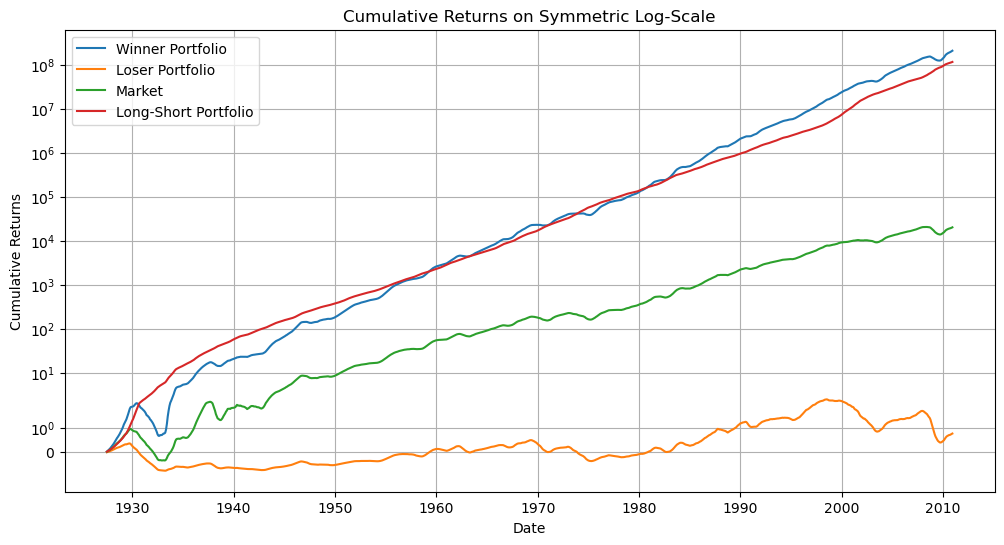

```python
import numpy as np
import matplotlib.pyplot as plt

# Calculate cumulative returns for each portfolio
cumulative_returns_winner = (1 + average_returns_winner_portfolio).cumprod() - 1
cumulative_returns_loser = (1 + average_returns_loser_portfolio).cumprod() - 1
cumulative_returns_market = (1 + average_market_return).cumprod() - 1
cumulative_returns_long_short = (1 + long_short_returns).cumprod() - 1

# Plot cumulative returns on a symmetric log-scale
plt.figure(figsize=(12, 6))

plt.plot(cumulative_returns_winner, label='Winner Portfolio')
plt.plot(cumulative_returns_loser, label='Loser Portfolio')
plt.plot(cumulative_returns_market, label='Market')
plt.plot(cumulative_returns_long_short, label='Long-Short Portfolio')

plt.yscale('symlog')
plt.xlabel('Date')
plt.ylabel('Cumulative Returns')
plt.title('Cumulative Returns on Symmetric Log-Scale')
plt.legend()
plt.grid(True)
plt.show()
```

QUESTION 2 - PART 6 STARTS HERE

```python
import pandas as pd

# Filter the data for the year 2009
long_short_returns_2009 = long_short_returns.loc['2009-01-01':'2009-12-31']
average_market_return_2009 = average_market_return.loc['2009-01-01':'2009-12-31']

# Display the long-short returns and market returns for 2009
print("Long-Short Portfolio Returns for 2009:")
print(long_short_returns_2009)

print("\nMarket Returns for 2009:")
print(average_market_return_2009)
```

```
Long-Short Portfolio Returns for 2009:
2009-01-01    0.028221
2009-02-01    0.031884
2009-03-01    0.036973
2009-04-01    0.031375
2009-05-01    0.023054
2009-06-01    0.020633
2009-07-01    0.025018
2009-08-01    0.020219
2009-09-01    0.015856
2009-10-01    0.012108
2009-11-01    0.018567
2009-12-01    0.025737
Name: Return, dtype: float64

Market Returns for 2009:
Date yyyy/mm
2009-01-01   -0.038254
2009-02-01   -0.041059
2009-03-01   -0.049188
2009-04-01   -0.040826
2009-05-01   -0.030594
2009-06-01   -0.028793
2009-07-01   -0.022649
2009-08-01   -0.011972
2009-09-01   -0.010863
2009-10-01    0.003024
2009-11-01    0.017529
2009-12-01    0.030420
dtype: float64
```

```python
# Identify the worst three-month period in 2009 for the long-short portfolio
long_short_2009 = long_short_returns_2009
worst_three_months = long_short_2009.rolling(window=3).sum().idxmin()
worst_three_months_range = pd.date_range(worst_three_months - pd.DateOffset(months=2), worst_three_months, freq='MS')

# Calculate the cumulative loss for the long-short portfolio during this period
cumulative_loss_long_short = long_short_returns[worst_three_months_range].sum()

# Calculate the market performance during this period
cumulative_loss_market = average_market_return[worst_three_months_range].sum()

# Print the results
print(f"Worst three-month period for Long-Short Portfolio in 2009: {worst_three_months}")
print(f"Months during this period: {worst_three_months_range.strftime('%Y-%m').tolist()}")
print(f"Losses during this period for Long-Short Portfolio: {cumulative_loss_long_short}")
print(f"Market performance during this period: {cumulative_loss_market}")
```

```
Worst three-month period for Long-Short Portfolio in 2009: 2009-11-01 00:00:00
Months during this period: ['2009-09', '2009-10', '2009-11']
Losses during this period for Long-Short Portfolio: 0.04653055555555555
Market performance during this period: 0.009690277777777777
```

END OF QUESTION 2